# Group_project_draft

Cody.ke

2025-12-09

## R Markdown

[output not shown]

[output cut: 28 more lines]

[output not shown]

## 0. Data Preprocessing Step

LAPD switched to a new records management system in March 7th 2024 (the number of crimes in this dataset drops significantly after that), so we’re going to ignore 2024 in total.

```r
crime_data <- read.csv("Crime_Data_from_2020_to_Present.csv")
crime_data <- crime_data %>%
  mutate(
    date = as.Date(substring(Date.Rptd, 1, 10), format = "%m/%d/%Y"),
    year  = year(date),
    month = month(date)
  ) %>%
  arrange(date) %>%
  filter(year < 2024) # drop the year 2024

colnames(crime_data)
```

```
##  [1] "DR_NO"          "Date.Rptd"      "DATE.OCC"       "TIME.OCC"
##  [5] "AREA"           "AREA.NAME"      "Rpt.Dist.No"    "Part.1.2"
##  [9] "Crm.Cd"         "Crm.Cd.Desc"    "Mocodes"        "Vict.Age"
## [13] "Vict.Sex"       "Vict.Descent"   "Premis.Cd"      "Premis.Desc"
## [17] "Weapon.Used.Cd" "Weapon.Desc"    "Status"         "Status.Desc"
## [21] "Crm.Cd.1"       "Crm.Cd.2"       "Crm.Cd.3"       "Crm.Cd.4"
## [25] "LOCATION"       "Cross.Street"   "LAT"            "LON"
## [29] "date"           "year"           "month"
```

## 1. Crime Over Time — Has Crime Increased or Decreased?

This plot shows reported crimes per day in LA from 2020 to 2023. The blue curve captures detailed fluctuations, while the red line shows a linear trend across the entire period.

The trend suggests that crime increased from 2020 through 2022, with a noticeable uptick between 2021 and 2022. This could be due to the COVID-19 lockdown in 2020, when many types of crime were suppressed. As the city reopened and activity returned closer to normal in 2021 and 2022, the daily crime counts rose accordingly.

By 2023, the smoothed curve appears to level off, indicating that crime may have stabilized or begun to decrease relative to the peak around 2022.

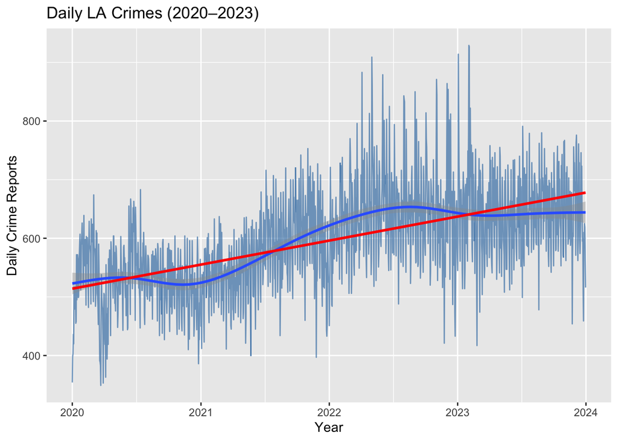

```r
crime_data %>%
  group_by(date) %>%
  summarise(n = n()) %>%
  ggplot(aes(date, n)) +
  geom_line(color="steelblue", alpha=0.7) +
  geom_smooth() +
  geom_smooth(method="lm", se=FALSE, color="red") +
  labs(
    title = "Daily LA Crimes (2020–2023)",
    x = "Year",
    y = "Daily Crime Reports"
  )
```

## 1.5. Inference on mean daily crimes in 2020 vs mean daily crimes in 2022.

```r
# 1. Compute daily crime counts
daily_counts <- crime_data %>%
  group_by(date) %>%
  summarise(n = n()) %>%
  ungroup() %>%
  mutate(year = year(date))

# 2. Pull out the two samples
crime_2020 <- daily_counts %>% filter(year == 2020) %>% pull(n)
crime_2022 <- daily_counts %>% filter(year == 2022) %>% pull(n)

t.test(
  crime_2020,
  crime_2022,
  alternative = "less",
  var.equal = FALSE
)
```

```
##
##  Welch Two Sample t-test
##
## data:  crime_2020 and crime_2022
## t = -22.501, df = 670.72, p-value < 2.2e-16
## alternative hypothesis: true difference in means is less than 0
## 95 percent confidence interval:
##       -Inf -108.8937
## sample estimates:
## mean of x mean of y
##  526.5246  644.0192
```

The Welch’s t-test returns a p-value of 2.2e-16, so there’s significant evidence to suggest that the daily average crime in 2020 was less than that of 2022.

## 2. Crime by Location (Area) — Which Neighborhoods Are Most Affected?

To understand how crime is distributed geographically, we first examine the total number of reported crimes across LAPD areas. In general, divisions such as 77th Street, Central, and Pacific consistently report the highest volumes of crime.

However, since our main research question focuses on how crime changes over time, we also break this data down to capture yearly dynamics by the color of the bars (2020–2023).

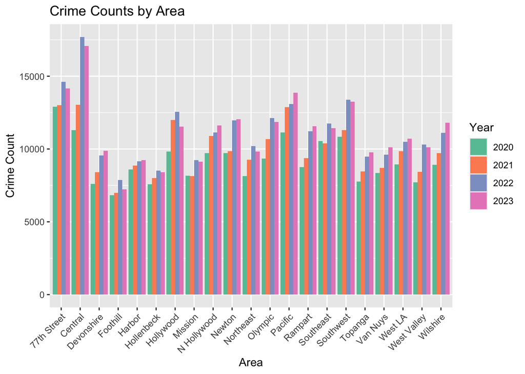

```r
crime_yearly <- crime_data %>%
  filter(year %in% c(2020, 2021, 2022, 2023))

crime_yearly %>%
  group_by(AREA.NAME, year) %>%
  summarise(n = n(), .groups = "drop") %>%
  ggplot(aes(x = AREA.NAME, y = n, fill = as.factor(year))) +
  geom_bar(stat = "identity", position = position_dodge()) +
  scale_fill_brewer(palette = "Set2", name = "Year") +
  theme(axis.text.x = element_text(angle = 45, hjust = 1)) +
  labs(
    title = "Crime Counts by Area",
    x = "Area",
    y = "Crime Count"
  )
```

## 3. Crime by Victim Sex — How Has It Changed Over Time?

To examine gender patterns in crime victims, we look at the number of reported victims by sex (Male vs Female). Again, rather than summarizing all years together, we group incidents by year to see whether the distribution changes over time.

By plotting the yearly counts for male and female victims, we see that the relative proportions remain fairly consistent across the years, with male victims consistently outnumbering female victims.

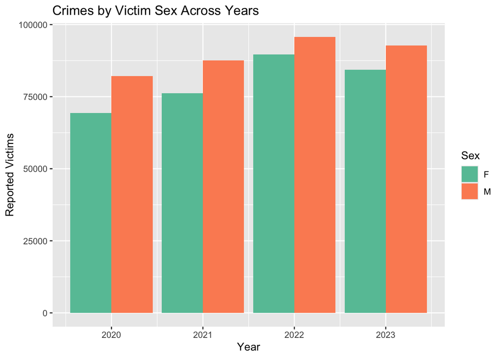

```r
crime_sex_year <- crime_data %>%
  filter(Vict.Sex %in% c("M", "F")) %>%
  group_by(year, Vict.Sex) %>%
  summarise(n = n(), .groups = "drop")

crime_sex_year %>%
  ggplot(aes(x = year, y = n, fill = Vict.Sex)) +
  geom_bar(stat = "identity", position = "dodge") +
  scale_fill_brewer(palette = "Set2") +
  labs(
    x = "Year",
    y = "Reported Victims",
    fill = "Sex",
    title = "Crimes by Victim Sex Across Years"
  )
```

# 3.5 Inference on proportion of male victims in 2020 vs 2022.

Even though the plot showed us that there were always more male victims compared to female victims, we can still conduct a two proportion z-test to see whether the proportion of male victims changed significantly between 2020 and 2022. Visually, we can see that 2020 has slightly more male victims than female victims, so we want to find if $p_{2020} > p{2022}$.

- Let $p_{2020}$ = true proportion of victims who were male in 2020
- Let $p_{2022}$ = true proportion of victims who were male in 2022
- Null: $p_{2020} = p{2022}$
- Alternative: $p_{2020} > p{2022}$

```r
# Extract year and filter valid sexes
sex_year <- crime_data %>%
  filter(Vict.Sex %in% c("M", "F")) %>%
  mutate(year = year(date)) %>%
  filter(year %in% c(2020, 2022))

# Count M/F by year
sex_counts <- sex_year %>%
  group_by(year, Vict.Sex) %>%
  summarise(n = n()) %>% ungroup()
# Extract counts
m2020 <- sex_counts$n[sex_counts$year == 2020 & sex_counts$Vict.Sex == "M"]
f2020 <- sex_counts$n[sex_counts$year == 2020 & sex_counts$Vict.Sex == "F"]

m2022 <- sex_counts$n[sex_counts$year == 2022 & sex_counts$Vict.Sex == "M"]
f2022 <- sex_counts$n[sex_counts$year == 2022 & sex_counts$Vict.Sex == "F"]

# Sample proportions
p2020 <- m2020 / (m2020 + f2020)
p2022 <- m2022 / (m2022 + f2022)

prop.test(
  x = c(m2020, m2022),
  n = c(m2020 + f2020, m2022 + f2022),
  alternative = "greater",
  correct = TRUE
)
```

```
##
##  2-sample test for equality of proportions with continuity correction
##
## data:  c(m2020, m2022) out of c(m2020 + f2020, m2022 + f2022)
## X-squared = 226.68, df = 1, p-value < 2.2e-16
## alternative hypothesis: greater
## 95 percent confidence interval:
##  0.0231877 1.0000000
## sample estimates:
##    prop 1    prop 2
## 0.5423262 0.5162906
```

```r
c(m2020, f2020, m2022, f2022)
```

```
## [1] 82157 69333 95743 89701
```